# Задача_графики_Gradov

```python
import pandas as pd
import matplotlib.pyplot as plt
import seaborn as sbs
import plotly
import plotly.express as px
plt.style.use('default')
```

```python
# Загрузка данных

churn_data = pd.read_csv('data/churn.csv')
churn_data.head()
```

|  | RowNumber | CustomerId | Surname | CreditScore | Geography | Gender | Age | Tenure | Balance | NumOfProducts | HasCrCard | IsActiveMember | EstimatedSalary | Exited |
| --- | --- | --- | --- | --- | --- | --- | --- | --- | --- | --- | --- | --- | --- | --- |
| 0 | 1 | 15634602 | Hargrave | 619 | France | Female | 42 | 2 | 0.00 | 1 | 1 | 1 | 101348.88 | 1 |
| 1 | 2 | 15647311 | Hill | 608 | Spain | Female | 41 | 1 | 83807.86 | 1 | 0 | 1 | 112542.58 | 0 |
| 2 | 3 | 15619304 | Onio | 502 | France | Female | 42 | 8 | 159660.80 | 3 | 1 | 0 | 113931.57 | 1 |
| 3 | 4 | 15701354 | Boni | 699 | France | Female | 39 | 1 | 0.00 | 2 | 0 | 0 | 93826.63 | 0 |
| 4 | 5 | 15737888 | Mitchell | 850 | Spain | Female | 43 | 2 | 125510.82 | 1 | 1 | 1 | 79084.10 | 0 |

Столбцы таблицы:

1. RowNumber — номер строки таблицы (это лишняя информация, поэтому можете сразу от неё избавиться)
2. CustomerId — идентификатор клиента
3. Surname — фамилия клиента
4. CreditScore — кредитный рейтинг клиента (чем он выше, тем больше клиент брал кредитов и возвращал их)
5. Geography — страна клиента (банк международный)
6. Gender — пол клиента
7. Age — возраст клиента
8. Tenure — сколько лет клиент пользуется услугами банка
9. Balance — баланс на счетах клиента в банке
10. NumOfProducts — количество услуг банка, которые приобрёл клиент
11. HasCrCard — есть ли у клиента кредитная карта (1 — да, 0 — нет)
12. IsActiveMember — есть ли у клиента статус активного клиента банка (1 — да, 0 — нет)
13. EstimatedSalary — предполагаемая заработная плата клиента
14. Exited — статус лояльности (1 — ушедший клиент, 0 — лояльный клиент)

Итак, банк обращается к вам за помощью: он хочет разработать кампанию лояльности по удержанию клиентов, но для этого ему необходимо, чтобы вы выяснили основные причины оттока клиентов. Иными словами, нужно установить, чем ушедшие клиенты отличаются от лояльных и как между собой связаны различные признаки, определяющие клиентов.

После разведывательного анализа, с целью выявления наиболее важных признаков оттока, банк сможет построить модель машинного обучения, которая будет прогнозировать уход клиента.

## Задания

### 9.2.

**Каково соотношение ушедших и лояльных клиентов? Покажите это на графике и дайте комментарий по соотношению.**

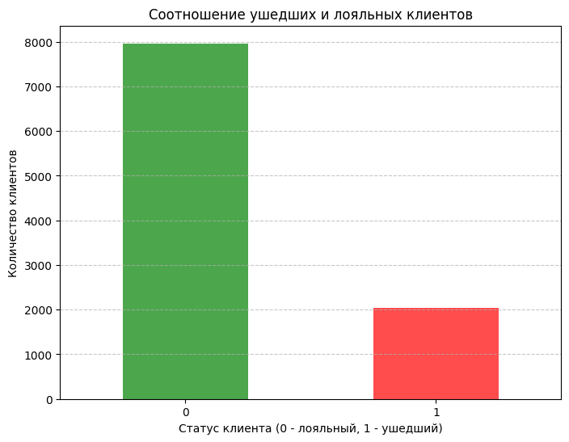

```
Лояльные клиенты: 79.63%
Ушедшие клиенты: 20.37%
```

```python
# Подсчет количества ушедших и лояльных клиентов
counts = churn_data['Exited'].value_counts()

# Построение графика
plt.figure(figsize=(8, 6))
counts.plot(kind='bar', color=['green', 'red'], alpha=0.7)
plt.title('Соотношение ушедших и лояльных клиентов')
plt.xlabel('Статус клиента (0 - лояльный, 1 - ушедший)')
plt.ylabel('Количество клиентов')
plt.xticks(rotation=0)
plt.grid(axis='y', linestyle='--', alpha=0.7)

# Показ графика
plt.show()

# Расчет долей
loyal_ratio = counts[0] / counts.sum()
exited_ratio = counts[1] / counts.sum()

print(f"Лояльные клиенты: {loyal_ratio:.2%}")
print(f"Ушедшие клиенты: {exited_ratio:.2%}")
```

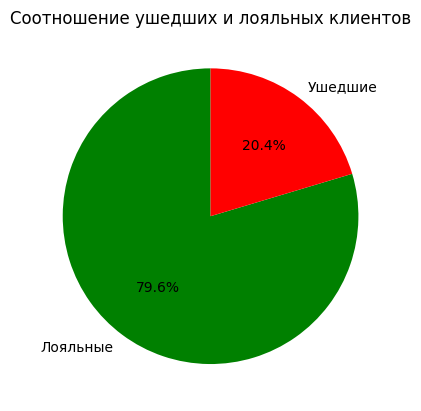

```python
counts.plot(kind='pie', autopct='%1.1f%%', colors=['green', 'red'], startangle=90, labels=['Лояльные', 'Ушедшие'])
plt.title('Соотношение ушедших и лояльных клиентов')
plt.ylabel('')  # Убираем метку оси Y
plt.show()
```

**Комментарий к диаграммам:**

Диаграмма наглядно подтверждает, что большая часть клиентов лояльна банку (79.63%), в то время как ушедшие клиенты составляют 20.37%.

Хотя процент ушедших клиентов не является катастрофическим, он всё равно может оказать значительное влияние на доходность банка, особенно если это клиенты с высокими балансами или кредитными рейтингами. Поэтому важно разработать стратегии для уменьшения этого процента.

Рекомендации:

- Удержание клиентов: Для дальнейшего снижения оттока стоит провести анализ факторов, которые могут повлиять на уход клиентов, например, недостаток активных продуктов, низкий кредитный рейтинг или отсутствие кредитных карт.
- Целевая кампания: Возможно, стоит сосредоточиться на группах клиентов, которые наиболее склонны к уходу (например, те, у кого низкий баланс или активность), и предложить им персонализированные условия или дополнительные услуги для повышения лояльности.
1. Столбчатая диаграмма показывает четкое соотношение между ушедшими и лояльными клиентами.
2. Круговая диаграмма наглядно отображает процентное соотношение ушедших и лояльных клиентов.

### 9.2.

**Постройте график, показывающий распределение баланса пользователей, у которых на счету больше 2 500 долларов. Опишите распределение и сделайте выводы.**

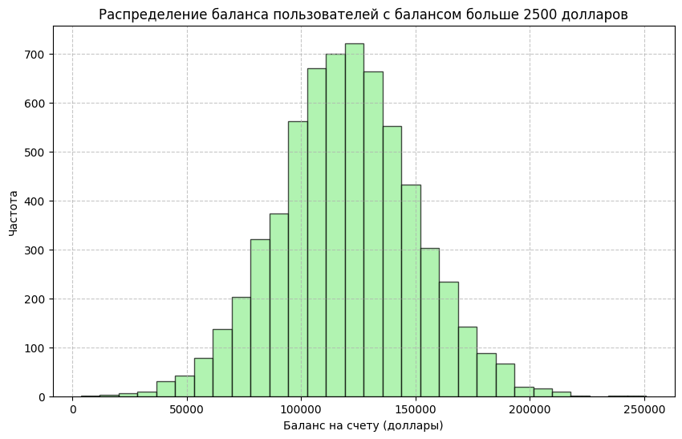

```
count      6383.000000
mean     119827.493793
std       30095.056462
min        3768.690000
25%      100181.975000
50%      119839.690000
75%      139512.290000
max      250898.090000
Name: Balance, dtype: float64
```

```python
# Фильтрация данных по балансу больше 2500
df_filtered = churn_data[churn_data['Balance'] > 2500]

# Построение гистограммы
plt.figure(figsize=(10, 6))
plt.hist(df_filtered['Balance'], bins=30, color='lightgreen', edgecolor='black', alpha=0.7)
plt.title('Распределение баланса пользователей с балансом больше 2500 долларов')
plt.xlabel('Баланс на счету (доллары)')
plt.ylabel('Частота')
plt.grid(True, linestyle='--', alpha=0.7)

# Показать график
plt.show()

# Вывод статистики
print(df_filtered['Balance'].describe())
```

**Статистические данные:**

- Количество клиентов: 6383
- Средний баланс: 119,827.49 долларов
- Стандартное отклонение: 30,095.06 долларов
- Минимальный баланс: 3,768.69 долларов
- 25-й процентиль (Q1): 100,181.98 долларов
- Медиана (50-й процентиль): 119,839.69 долларов
- 75-й процентиль (Q3): 139,512.29 долларов
- Максимальный баланс: 250,898.09 долларов

**Описание распределения:**

1. Среднее значение (119,827.49 долларов) достаточно высокое, что указывает на то, что в среднем клиенты имеют значительные суммы на счетах. Это говорит о том, что банк обслуживает клиентов с достаточно высокими финансовыми возможностями.
2. Минимальный баланс (3,768.69 долларов) довольно низкий, что говорит о наличии клиентов с относительно небольшими суммами на счетах. Однако, это значение все равно значительно выше 2 500 долларов, что делает эту выборку релевантной для анализа.
3. Стандартное отклонение (30,095.06 долларов) показывает, что существует значительная вариативность в балансах клиентов. Это означает, что среди клиентов есть как те, кто держит на счетах относительно небольшие суммы, так и те, у кого гораздо большие суммы. Это может указывать на широкое разнообразие в финансовом положении клиентов.
4. Процентили:
- 25-й процентиль (100,181.98 долларов) показывает, что 25% клиентов имеют баланс ниже этой суммы.
- Медиана (50-й процентиль) на уровне 119,839.69 долларов говорит о том, что половина клиентов имеет баланс ниже этого значения, а другая половина — выше.
- 75-й процентиль (139,512.29 долларов) показывает, что 75% клиентов имеют баланс ниже этой суммы, и только 25% имеют баланс выше.
5. Максимальный баланс (250,898.09 долларов) указывает на наличие клиентов с очень высокими суммами на счетах, что может быть связано с "премиум" клиентами.

**Выводы:**

- Склонность к высокому балансу: Средний баланс и медиана (около 120,000 долларов) показывают, что большинство клиентов имеют достаточно высокие суммы на счетах, что свидетельствует о клиентской базе среднего и выше среднего уровня. Это может указывать на стабильность и финансовую устойчивость банка.
- Большая вариативность: Стандартное отклонение в 30,095 долларов подтверждает, что существует значительная вариативность среди клиентов. Хотя большинство клиентов имеет баланс в пределах 100,000–140,000 долларов, некоторые могут иметь гораздо меньшие или большие суммы. Это также подтверждается максимальным значением, которое почти в два раза превышает средний баланс.
- Премиум клиенты: Наличие клиентов с балансом до 250,000 долларов говорит о присутствии в клиентской базе крупных вкладчиков, что может быть важным сегментом для банка.
- Умеренная концентрация: 50% клиентов имеют баланс от 100,000 до 140,000 долларов, что может быть индикатором того, что большинство клиентов находится в этом диапазоне, и банк может сосредоточиться на удержании этого сегмента.

Таким образом, банк имеет разнообразную клиентскую базу с достаточно высокими средними балансами, что важно для стратегии управления активами и маркетинга.

### 9.3.

**Посмотрите на распределение баланса клиента в разрезе признака оттока. Как различаются суммы на накопительном счёте ушедших и лояльных клиентов? Подумайте и напишите, с чем это может быть связано, что может не устраивать ушедших клиентов в банке.**

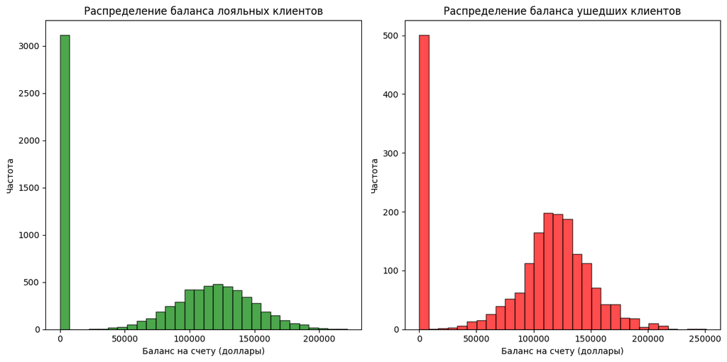

```
Статистика для лояльных клиентов:
count      7963.000000
mean      72745.296779
std       62848.040701
min           0.000000
25%           0.000000
50%       92072.680000
75%      126410.280000
max      221532.800000
Name: Balance, dtype: float64

Статистика для ушедших клиентов:
count      2037.000000
mean      91108.539337
std       58360.794816
min           0.000000
25%       38340.020000
50%      109349.290000
75%      131433.330000
max      250898.090000
Name: Balance, dtype: float64
```

```python
# Разделение данных на лояльных и ушедших клиентов
loyal_customers = churn_data[churn_data['Exited'] == 0]
exited_customers = churn_data[churn_data['Exited'] == 1]

# Построение гистограммы для лояльных клиентов
plt.figure(figsize=(12, 6))

plt.subplot(1, 2, 1)
plt.hist(loyal_customers['Balance'], bins=30, color='green', edgecolor='black', alpha=0.7)
plt.title('Распределение баланса лояльных клиентов')
plt.xlabel('Баланс на счету (доллары)')
plt.ylabel('Частота')

# Построение гистограммы для ушедших клиентов
plt.subplot(1, 2, 2)
plt.hist(exited_customers['Balance'], bins=30, color='red', edgecolor='black', alpha=0.7)
plt.title('Распределение баланса ушедших клиентов')
plt.xlabel('Баланс на счету (доллары)')
plt.ylabel('Частота')

# Показать графики
plt.tight_layout()
plt.show()

# Статистические данные для сравнения
print("Статистика для лояльных клиентов:")
print(loyal_customers['Balance'].describe())

print("\nСтатистика для ушедших клиентов:")
print(exited_customers['Balance'].describe())
```

**Статистика:**

1. Лояльные клиенты:
- Средний баланс: 72,745.30 долларов
- Минимальный баланс: 0 долларов (возможно, это клиенты с нулевыми или очень низкими суммами на счетах)
- 25-й процентиль (Q1): 0 долларов (половина клиентов имеет баланс менее 92,072.68 долларов)
- Медиана: 92,072.68 долларов (половина лояльных клиентов имеют баланс ниже этой суммы)
- Максимальный баланс: 221,532.80 долларов
2. Ушедшие клиенты:
- Средний баланс: 91,108.54 долларов
- Минимальный баланс: 0 долларов
- 25-й процентиль (Q1): 38,340.02 долларов
- Медиана: 109,349.29 долларов
- Максимальный баланс: 250,898.09 долларов

**Анализ различий:**

1. Средний баланс:
- У ушедших клиентов средний баланс значительно выше (91,108.54 долларов), чем у лояльных клиентов (72,745.30 долларов).
- Это может указывать на то, что клиенты с более высокими суммами на счетах, возможно, ожидают более высоких уровней обслуживания, и если банк не оправдывает их ожидания, они могут покинуть его.
2. Минимальный баланс:
- Как у лояльных, так и у ушедших клиентов есть клиенты с нулевыми балансами, что может указывать на счета, которые не используются активно или на клиентов, которые недавно начали использовать услуги банка. Однако для ушедших клиентов этот факт может быть связан с уходом клиентов, у которых баланс стал равным нулю, возможно, из-за списания средств.
3. Процентили:
- Для лояльных клиентов 25% имеют баланс 0 долларов, что может свидетельствовать о наличии клиентов с очень низкими суммами или даже без средств на счетах. Это может быть связано с тем, что они не пользуются активными услугами банка, но при этом остаются в качестве клиентов.
- У ушедших клиентов 25% имеют баланс в районе 38,340.02 долларов, что значительно выше, чем у лояльных. Это может говорить о том, что ушедшие клиенты в среднем имеют более высокие суммы на счетах, но, возможно, не удовлетворены условиями обслуживания, что привело к их уходу.
4. Медиана:
- Медиана для лояльных клиентов (92,072.68 долларов) и для ушедших клиентов (109,349.29 долларов) показывает, что большинство ушедших клиентов имеют более высокие суммы на счетах. Это также может свидетельствовать о том, что клиенты с более высокими суммами, скорее всего, ожидали более качественного обслуживания, что может объяснять их уход.
5. Максимальный баланс:
- Максимальные значения для обеих групп — 221,532.80 долларов (лояльные) и 250,898.09 долларов (ушедшие) — показывают, что среди ушедших клиентов есть несколько с очень большими суммами на счетах. Это может быть важным сигналом для банка, что высокобалансные клиенты могут быть более чувствительны к качеству обслуживания.

**Возможные причины ухода клиентов с высокими балансами:**

- Неудовлетворенность условиями обслуживания: Ушедшие клиенты с более высокими балансами могут ожидать более выгодных условий, например, по процентным ставкам, бонусам, привилегиям или более качественного обслуживания. Если банк не удовлетворяет эти ожидания, клиенты могут уйти к конкурентам.
- Высокие комиссии и расходы: Клиенты с высокими балансами могут быть более чувствительны к скрытым комиссиям или невыгодным условиям для крупных вкладчиков. Если банк не предлагает конкурентоспособные ставки или услуги, это может привести к уходу.
- Отсутствие персонализированного обслуживания: Клиенты с высокими суммами на счетах могут ожидать индивидуального подхода и премиум-услуг. Если банк не предоставляет такие услуги или не удовлетворяет ожидания клиентов в этом плане, это может стать причиной оттока.
- Конкуренция: Клиенты с большими суммами могут быть более склонны менять банк, если конкуренты предлагают более привлекательные условия (например, лучшие ставки по депозитам или кредитам, более выгодные условия для премиум-клиентов).

Отток клиентов с более высокими балансами может быть связан с их более высокими ожиданиями от банка. Чтобы уменьшить отток, банк должен сфокусироваться на улучшении условий для крупных клиентов, предложении премиум-услуг и персонализированного обслуживания.

### 9.4.

**Посмотрите на распределение возраста в разрезе признака оттока. В какой группе больше потенциальных выбросов? На какую возрастную категорию клиентов стоит обратить внимание банку?**

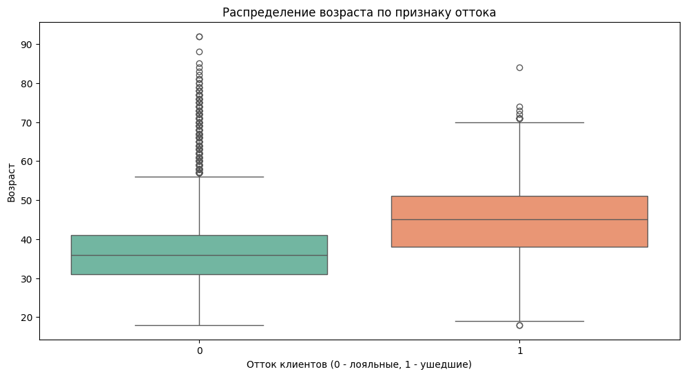

```
Статистика для лояльных клиентов:
count    7963.000000
mean       37.408389
std        10.125363
min        18.000000
25%        31.000000
50%        36.000000
75%        41.000000
max        92.000000
Name: Age, dtype: float64

Статистика для ушедших клиентов:
count    2037.000000
mean       44.837997
std         9.761562
min        18.000000
25%        38.000000
50%        45.000000
75%        51.000000
max        84.000000
Name: Age, dtype: float64
```

```python
# Разделение данных на лояльных и ушедших клиентов
loyal_customers = churn_data[churn_data['Exited'] == 0]
exited_customers = churn_data[churn_data['Exited'] == 1]

# Построение боксплота для возраста лояльных и ушедших клиентов
plt.figure(figsize=(12, 6))
sbs.boxplot(x='Exited', y='Age', data=churn_data, palette="Set2")

plt.title('Распределение возраста по признаку оттока')
plt.xlabel('Отток клиентов (0 - лояльные, 1 - ушедшие)')
plt.ylabel('Возраст')
plt.show()

# Статистическая информация по возрасту
print("Статистика для лояльных клиентов:")
print(loyal_customers['Age'].describe())

print("\nСтатистика для ушедших клиентов:")
print(exited_customers['Age'].describe())
```

**Статистика:**

1. Статистика для лояльных клиентов:
- Средний возраст: 37.41 лет
- Минимальный возраст: 18 лет
- 25-й процентиль (Q1): 31 лет
- Медиана: 36 лет
- 75-й процентиль (Q3): 41 лет
- Максимальный возраст: 92 года
2. Статистика для ушедших клиентов:
- Средний возраст: 44.84 года
- Минимальный возраст: 18 лет
- 25-й процентиль (Q1): 38 лет
- Медиана: 45 лет
- 75-й процентиль (Q3): 51 год
- Максимальный возраст: 84 года

**Основные выводы:**

**Что это может значить для банка:**

- Старшие клиенты (38-51 год): Для этой группы клиентов банк может разработать специализированные продукты или услуги, такие как пенсионные программы, более выгодные условия по кредитам или депозита, которые будут соответствовать их потребностям и ожиданиям.
- Молодые клиенты (18-37 лет): Молодые клиенты, вероятно, остаются лояльными, так как они только начинают взаимодействовать с банком. Банк может предложить им дополнительные продукты, такие как программы лояльности или бонусы за использование банковских услуг.
- Выбросы и нестандартные возрастные группы: Для ушедших клиентов старшего возраста стоит обратить внимание на возможные изменения в финансовых продуктах или обслуживании, которые могут быть неэффективны для этой возрастной группы, что может объяснить их уход.

Таким образом, для уменьшения оттока клиентов банк может сфокусироваться на создании персонализированных предложений для старших клиентов, улучшении условий для них и более активном вовлечении молодых клиентов через программы лояльности и специальные предложения.

### 9.5.

**Постройте график, который показывает взаимосвязь кредитного рейтинга клиента и его предполагаемой зарплаты. Добавьте расцветку по признаку оттока клиентов. Какова взаимосвязь между признаками? Если не видите явной взаимосвязи, укажите это.**

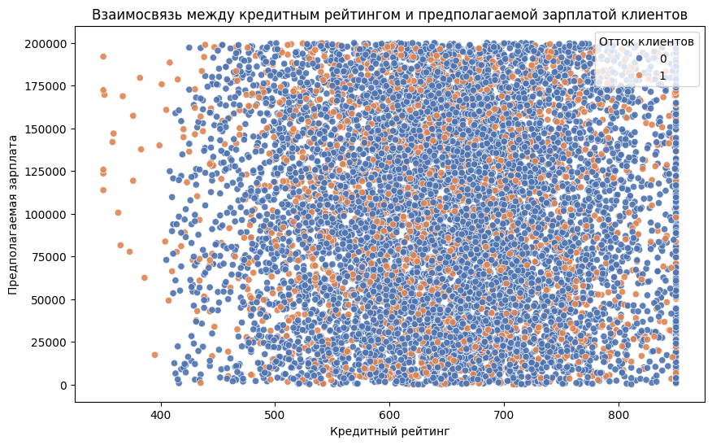

```
Статистика для лояльных клиентов:
       CreditScore  EstimatedSalary
count  7963.000000      7963.000000
mean    651.853196     99738.391772
std      95.653837     57405.586966
min     405.000000        90.070000
25%     585.000000     50783.490000
50%     653.000000     99645.040000
75%     718.000000    148609.955000
max     850.000000    199992.480000

Статистика для ушедших клиентов:
       CreditScore  EstimatedSalary
count  2037.000000      2037.000000
mean    645.351497    101465.677531
std     100.321503     57912.418071
min     350.000000        11.580000
25%     578.000000     51907.720000
50%     646.000000    102460.840000
75%     716.000000    152422.910000
max     850.000000    199808.100000
```

```python
# Построение диаграммы рассеяния с расцветкой по признаку оттока
plt.figure(figsize=(10, 6))
sbs.scatterplot(x='CreditScore', y='EstimatedSalary', hue='Exited', data=churn_data, palette='deep', alpha=0.9)

# Настройки графика
plt.title('Взаимосвязь между кредитным рейтингом и предполагаемой зарплатой клиентов')
plt.xlabel('Кредитный рейтинг')
plt.ylabel('Предполагаемая зарплата')
plt.legend(title='Отток клиентов', loc='upper right')
plt.show()

# Статистика по кредитному рейтингу и зарплате для лояльных и ушедших клиентов
loyal_clients_stats = churn_data[churn_data['Exited'] == 0][['CreditScore', 'EstimatedSalary']].describe()
churned_clients_stats = churn_data[churn_data['Exited'] == 1][['CreditScore', 'EstimatedSalary']].describe()

print("Статистика для лояльных клиентов:")
print(loyal_clients_stats)
print("\nСтатистика для ушедших клиентов:")
print(churned_clients_stats)
```

```python
# Корреляция между кредитным рейтингом и зарплатой
correlation = churn_data['CreditScore'].corr(churn_data['EstimatedSalary'])
print(f'Корреляция между кредитным рейтингом и зарплатой: {correlation:.2f}')
```

```
Корреляция между кредитным рейтингом и зарплатой: -0.00
```

```python
# Статистика по кредитному рейтингу и предполагаемой зарплате
credit_salary_stats = churn_data[['CreditScore', 'EstimatedSalary']].describe()
print(credit_salary_stats)
```

```
        CreditScore  EstimatedSalary
count  10000.000000     10000.000000
mean     650.528800    100090.239881
std       96.653299     57510.492818
min      350.000000        11.580000
25%      584.000000     51002.110000
50%      652.000000    100193.915000
75%      718.000000    149388.247500
max      850.000000    199992.480000
```

**Выводы по полученным данным:**

Заключение:

Кредитный рейтинг и зарплата в обеих группах не сильно отличаются. Это означает, что для удержания клиентов эти признаки не являются ключевыми индикаторами. Лояльные клиенты имеют немного выше медианный кредитный рейтинг, что может говорить о том, что банк удерживает клиентов с более стабильной финансовой историей.  
У ушедших клиентов зарплата в среднем выше, что может свидетельствовать о том, что они ищут лучшие условия обслуживания или продукты, которые больше соответствуют их уровню дохода. Банку стоит обратить внимание на клиентов с высоким доходом и средней кредитной историей, так как они могут быть более склонны к уходу.

### 9.6.

**Кто чаще уходит, мужчины или женщины? Постройте график, который иллюстрирует это.**

Подсказка  
Процент ушедших клиентов в каждой группе можно рассчитать как среднее по столбцу Exited (так как 1 — это ушедшие клиенты, а 0 — лояльные, среднее арифметическое по столбцу обозначает долю ушедших клиентов).

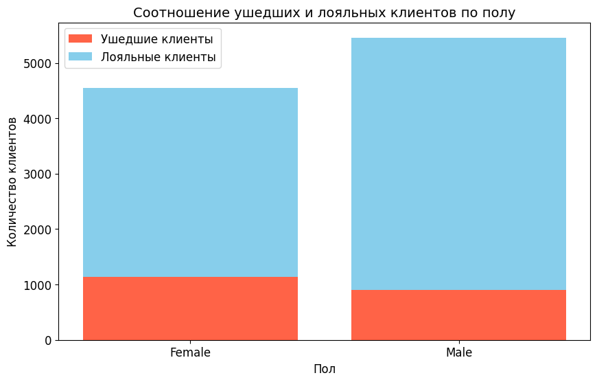

```python
# Группировка данных
gender_stats = churn_data.groupby('Gender').agg(
    TotalClients=('Exited', 'count'),
    ExitedClients=('Exited', 'sum'),
    LoyalClients=('Exited', lambda x: (x == 0).sum())
).reset_index()

# Построение составной диаграммы
plt.figure(figsize=(10, 6))
plt.bar(gender_stats['Gender'], gender_stats['ExitedClients'], label='Ушедшие клиенты', color='tomato')
plt.bar(gender_stats['Gender'], gender_stats['LoyalClients'], bottom=gender_stats['ExitedClients'], label='Лояльные клиенты', color='skyblue')

# Настройка графика
plt.title('Соотношение ушедших и лояльных клиентов по полу', fontsize=14)
plt.xlabel('Пол', fontsize=12)
plt.ylabel('Количество клиентов', fontsize=12)
plt.legend(fontsize=12)
plt.xticks(fontsize=12)
plt.yticks(fontsize=12)
plt.show()
```

```python
# Группировка по полу и расчет статистики
gender_stats = churn_data.groupby('Gender').agg(
    TotalClients=('Exited', 'count'),
    ExitedClients=('Exited', 'sum'),
    ExitRate=('Exited', 'mean')
).reset_index()

# Переименуем столбцы для удобства
gender_stats.columns = ['Gender', 'TotalClients', 'ExitedClients', 'ExitRate']

# Вывод статистики
print(gender_stats)
```

```
   Gender  TotalClients  ExitedClients  ExitRate
0  Female          4543           1139  0.250715
1    Male          5457            898  0.164559
```

**Подробный анализ данных**

Исходные данные:

1. Количество клиентов по полу:
- Женщины: 4,543 клиента.
- Мужчины: 5,457 клиентов.
2. Количество ушедших клиентов:
- Женщины: 1,139 ушедших клиентов.
- Мужчины: 898 ушедших клиентов.
3. Доля ушедших клиентов (ExitRate):
- Женщины: 25.07% (0.2507).
- Мужчины: 16.46% (0.1646).

**Интерпретация:**

1. Общее количество клиентов:
- Мужчин в выборке больше, чем женщин (54.57% против 45.43%). Это говорит о том, что мужчины составляют большую часть клиентской базы банка.
2. Доля ушедших клиентов:
- Женщины чаще уходят из банка, чем мужчины. Доля ушедших среди женщин составляет 25.07%, что значительно выше, чем у мужчин (16.46%). Это может свидетельствовать о том, что женщины менее удовлетворены услугами банка или более склонны переходить к конкурентам.
3. Абсолютное количество ушедших:
- Хотя женщин в клиентской базе меньше, их абсолютное количество среди ушедших (1,139) больше, чем у мужчин (898). Это подчеркивает, что проблема удержания женщин-клиентов для банка более остра.

**Возможные причины более высокого оттока среди женщин:**

1. Недостаточная персонализация услуг:
- Женщины могут иметь другие финансовые приоритеты (например, накопления, семейные расходы), которые банк не удовлетворяет в полной мере.
2. Меньшее вовлечение:
- Возможно, женщины менее вовлечены в долгосрочные финансовые продукты, которые связывают клиента с банком.
3. Конкуренция:
- Женщины могут быть более чувствительны к условиям обслуживания, предложениям и удобству других банков.

**Рекомендации банку:**

1. Персонализация продуктов:
- Разработать специальные предложения для женщин, учитывающие их финансовые потребности (например, продукты для накоплений или семейного бюджета).
2. Обратная связь:
- Провести опрос среди ушедших клиенток, чтобы понять их недовольство.
3. Улучшение клиентского опыта:
- Повысить удобство обслуживания (мобильные приложения, скорость обработки запросов).
4. Программы лояльности:
- Запустить акционные программы или бонусы, которые удержат женщин в качестве клиентов.

Банку стоит сосредоточиться на снижении оттока среди женщин, так как это самая уязвимая группа клиентов.

### 9.7.

**Как отток клиентов зависит от числа приобретённых у банка услуг? Для ответа на этот вопрос постройте многоуровневую столбчатую диаграмму.**

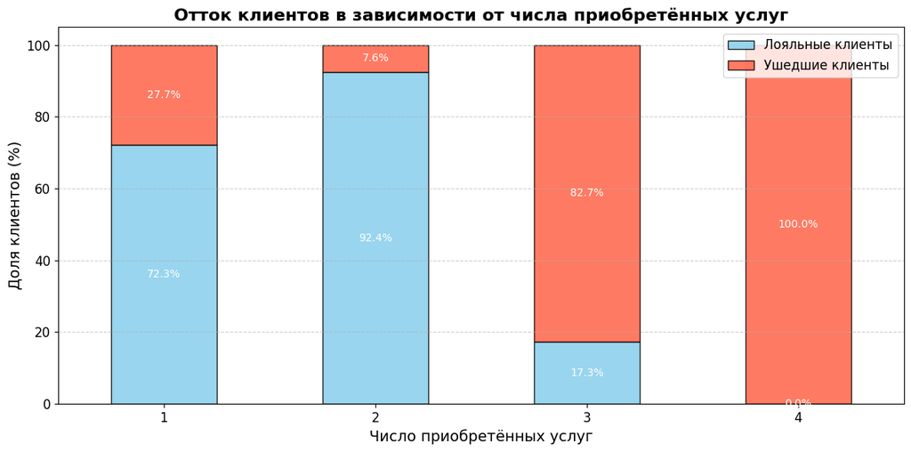

```python
# Группировка данных
services_stats = churn_data.groupby(['NumOfProducts', 'Exited']).size().unstack(fill_value=0)

# Преобразуем данные в проценты для анализа
services_stats_percent = services_stats.div(services_stats.sum(axis=1), axis=0) * 100

# Построение графика
plt.figure(figsize=(12, 6))
bars = services_stats_percent.plot(
    kind='bar',
    stacked=True,
    figsize=(12, 6),
    color=['skyblue', 'tomato'],
    alpha=0.85,
    edgecolor='black'
)

# Настройка аннотаций
for container in bars.containers:
    bars.bar_label(container, fmt='%.1f%%', label_type='center', fontsize=10, color='white')

# Настройка графика
plt.title('Отток клиентов в зависимости от числа приобретённых услуг', fontsize=16, fontweight='bold')
plt.xlabel('Число приобретённых услуг', fontsize=14)
plt.ylabel('Доля клиентов (%)', fontsize=14)
plt.xticks(rotation=0, fontsize=12)
plt.yticks(fontsize=12)
plt.legend(['Лояльные клиенты', 'Ушедшие клиенты'], fontsize=12, loc='upper right')
plt.tight_layout()
plt.grid(axis='y', linestyle='--', alpha=0.6)

# Отображение графика
plt.show()
```

```python
# Рассчитываем процент ушедших клиентов по числу услуг
exit_rate_by_services = churn_data.groupby('NumOfProducts')['Exited'].mean() * 100

# Выводим статистику для процентного оттока
statistics = exit_rate_by_services.describe()

# Печатаем статистику
print(statistics)
```

```
count      4.000000
mean      54.500716
std       43.911529
min        7.581699
25%       22.681223
50%       55.210583
75%       87.030075
max      100.000000
Name: Exited, dtype: float64
```

**Выводы:**

Таким образом, для эффективной кампании по удержанию клиентов банк должен провести более детальный анализ, чтобы понять, какие именно группы клиентов с определённым числом услуг склонны к уходу, и разработать стратегии для снижения оттока среди них.

### 9.8.

**Как влияет наличие статуса активного клиента на отток клиентов? Постройте диаграмму, иллюстрирующую это. Что бы вы предложили банку, чтобы уменьшить отток клиентов среди неактивных?**

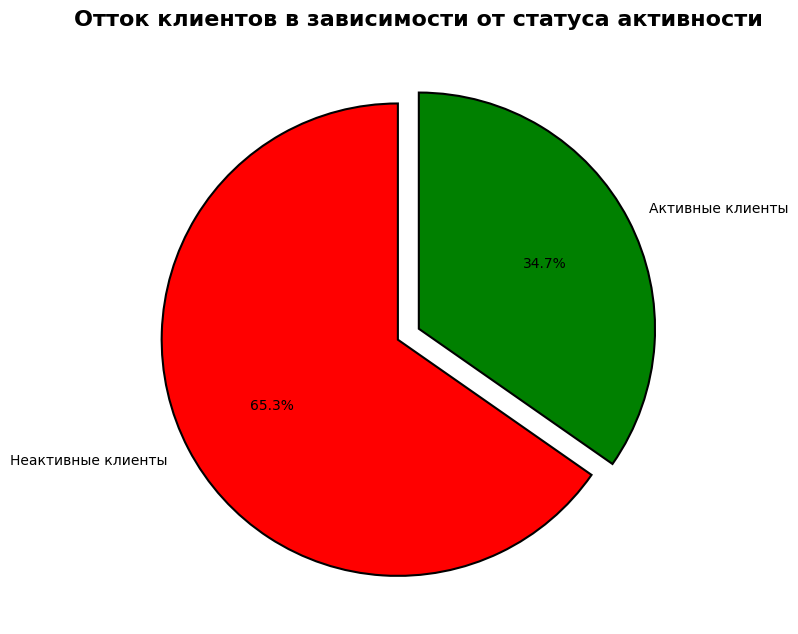

```python
# Рассчитаем процент ушедших клиентов для активных и неактивных
exit_rate_by_activity = churn_data.groupby('IsActiveMember')['Exited'].mean() * 100

# Данные для круговой диаграммы
labels = ['Неактивные клиенты', 'Активные клиенты']
sizes = exit_rate_by_activity.values
colors = ['red', 'green']
explode = (0.1, 0)  # Выделим неактивных клиентов

# Построение круговой диаграммы
plt.figure(figsize=(8, 8))
plt.pie(sizes, explode=explode, labels=labels, colors=colors, autopct='%1.1f%%', startangle=90,
        wedgeprops={'edgecolor': 'black', 'linewidth': 1.5, 'linestyle': 'solid'})

# Заголовок
plt.title('Отток клиентов в зависимости от статуса активности', fontsize=16, fontweight='bold')

# Отображение графика
plt.tight_layout()
plt.show()
```

```python
# Рассчитываем статистику для оттока по статусу активности
exit_stats_by_activity = churn_data.groupby('IsActiveMember')['Exited'].describe()

# Выводим статистику
print(exit_stats_by_activity)
```

```
                 count      mean       std  min  25%  50%  75%  max
IsActiveMember
0               4849.0  0.268509  0.443230  0.0  0.0  0.0  1.0  1.0
1               5151.0  0.142691  0.349791  0.0  0.0  0.0  0.0  1.0
```

**Статистика:**

1. Неактивные клиенты (IsActiveMember = 0):
- Средний процент оттока: 26.85% (0.268509)
- Стандартное отклонение: 44.32% (высокая изменчивость оттока среди неактивных клиентов).
- Минимальное значение оттока: 0%, максимальное значение: 100%.
- 25% клиентов имеют отток 0%, 50% — также 0%, и 75% — имеют отток 100%. Это означает, что среди неактивных клиентов есть значительная группа, которая осталась лояльной, и есть клиенты, которые ушли.
2. Активные клиенты (IsActiveMember = 1):
- Средний процент оттока: 14.27% (0.142691)
- Стандартное отклонение: 34.98% (меньшая изменчивость по сравнению с неактивными клиентами).
- Минимальное значение оттока: 0%, максимальное значение: 100%.
- 25% клиентов имеют отток 0%, 50% — также 0%, и 75% — имеют отток 0%. Это указывает на то, что большинство активных клиентов остаются лояльными, и лишь небольшая доля уходит.

**Выводы:**

1. Активные клиенты имеют значительно меньший процент оттока (14.27%) по сравнению с неактивными клиентами (26.85%). Это свидетельствует о том, что статус активности клиента в банке является важным фактором, влияющим на его лояльность. Неактивные клиенты более склонны уходить, возможно, потому, что они не вовлечены в процесс обслуживания или не получают достаточную ценность от услуг банка.
2. Неактивные клиенты показывают более высокое стандартное отклонение в проценте оттока, что говорит о том, что среди них есть как очень лояльные клиенты, так и те, кто ушел.

**Рекомендации для банка:**

Чтобы уменьшить отток клиентов среди неактивных:

1. Повышение вовлеченности: Банк должен предложить дополнительные стимулы для активации клиентов, такие как персонализированные предложения, бонусы за активность, консультации по использованию дополнительных услуг.
2. Обучение и поддержка: Банку стоит провести образовательные кампании, чтобы показать неактивным клиентам, как можно извлечь максимальную пользу из предлагаемых продуктов и услуг.
3. Регулярная связь с клиентами: Важно поддерживать контакт с клиентами через электронную почту, SMS или мобильное приложение, напоминая о возможностях и акциях, доступных в банке.
4. Анализ причин неактивности: Провести опросы или анализ поведения клиентов, чтобы понять, почему они не используют услуги банка. Возможно, есть проблемы с продуктами или с клиентским обслуживанием.
5. Персонализированные предложения: Для неактивных клиентов можно предложить персонализированные скидки или улучшенные условия на продукты банка, чтобы вернуть их к активному использованию.

Эти шаги помогут банку не только снизить отток среди неактивных клиентов, но и повысить общую лояльность клиентов.

### 9.9.

**В какой стране доля ушедших клиентов больше? Постройте тепловую картограмму, которая покажет это соотношение на карте мира. Предположите, с чем это может быть связано.**

```python
# Группируем данные по странам и рассчитываем долю ушедших клиентов
country_exit_rate = churn_data.groupby('Geography')['Exited'].mean()

# Преобразуем данные в DataFrame для удобной работы
country_exit_rate = country_exit_rate.reset_index()
country_exit_rate.columns = ['Country', 'ExitRate']

# Проверяем данные
print(country_exit_rate.head())
```

```
   Country  ExitRate
0   France  0.161548
1  Germany  0.324432
2    Spain  0.166734
```

```python
import plotly.express as px

# Построение тепловой карты
fig = px.choropleth(country_exit_rate,
                    locations="Country",
                    locationmode="country names",  # Используем название страны
                    color="ExitRate",
                    color_continuous_scale="Viridis",  # Выбираем цветовую шкалу
                    labels={"ExitRate": "Доля ушедших клиентов (%)"},
                    title="Доля ушедших клиентов по странам")

# Отображаем карту
fig.show()
```

[output not shown]

**Анализ данных:**

Из предоставленных данных мы видим следующие значения для доли ушедших клиентов:

- France: 16.15%
- Germany: 32.44%
- Spain: 16.67%

Из этого можно сделать вывод, что Germany (Германия) имеет наибольшую долю ушедших клиентов — 32.44%.

**Возможные причины более высокого оттока в Германии:**

1. Конкуренция на рынке: Германия — одна из самых экономически развитых стран Европы с высокоразвитыми финансовыми рынками. В таких странах конкуренция между банками может быть особенно жесткой. Клиенты могут уходить в поисках более выгодных условий, лучших продуктов или более удобных сервисов, таких как мобильные приложения и онлайн-банкинг.
2. Качество обслуживания: Если клиенты в Германии чувствуют, что банк не удовлетворяет их потребности или что качество обслуживания недостаточно высоко, это может привести к более высокому оттоку. Например, долгие ожидания в обслуживании, недостаток персонализированных предложений или проблемы с доступностью продуктов и услуг.
3. Экономические факторы: Германия, несмотря на свою стабильную экономику, может испытывать экономические колебания или изменения в законодательстве, которые могут повлиять на поведение клиентов. Например, изменения в налоговом законодательстве или в банковских правилах могут повлиять на финансовое поведение клиентов.
4. Финансовая грамотность: В странах с высокоразвитыми рынками, такими как Германия, клиенты могут быть более финансово грамотными и осведомленными о возможностях на рынке. Это может означать, что они легче переключаются между банками, если не удовлетворены текущими условиями.
5. Технологические инновации: В странах с высоким уровнем цифровизации, таких как Германия, клиенты могут уходить к более инновационным банкам, которые предлагают более удобные или продвинутые технологии, такие как мобильные платежи, цифровые кошельки или инвестиционные платформы.

**Предложения для банка:**

Для уменьшения оттока клиентов в Германии банк может:

- Улучшить качество обслуживания: Важно инвестировать в обучение сотрудников, улучшить поддержку клиентов и предоставить более персонализированные услуги.
- Внедрить инновации: Внедрение новых технологий, таких как мобильные приложения, искусственный интеллект для персонализированных предложений и чат-боты для улучшения взаимодействия с клиентами.
- Анализировать конкурентные предложения: Провести исследование конкурентных предложений на рынке и, возможно, пересмотреть условия для привлечения и удержания клиентов.
- Обратить внимание на лояльность клиентов: Ввести программы лояльности или специальные предложения для клиентов, которые могут стимулировать их оставаться с банком.

Эти шаги помогут снизить отток и повысить лояльность клиентов в Германии.

### 9.10.

**Переведите числовой признак CreditScore в категориальный. Для этого воспользуйтесь функцией get_credit_score_cat(), которая приведена ниже. Примените её к столбцу CreditScore и создайте новый признак CreditScoreCat — категории кредитного рейтинга.**

Постройте сводную таблицу, строками которой являются категории кредитного рейтинга (CreditScoreCat), а столбцами — количество лет, в течение которых клиент пользуется услугами банка (Tenure). В ячейках сводной таблицы должно находиться среднее по признаку оттока (Exited) — доля ушедших пользователей.

На основе полученной сводной таблицы постройте тепловую карту с аннотацией. Найдите на тепловой карте категории клиентов, которые уходят чаще всего.

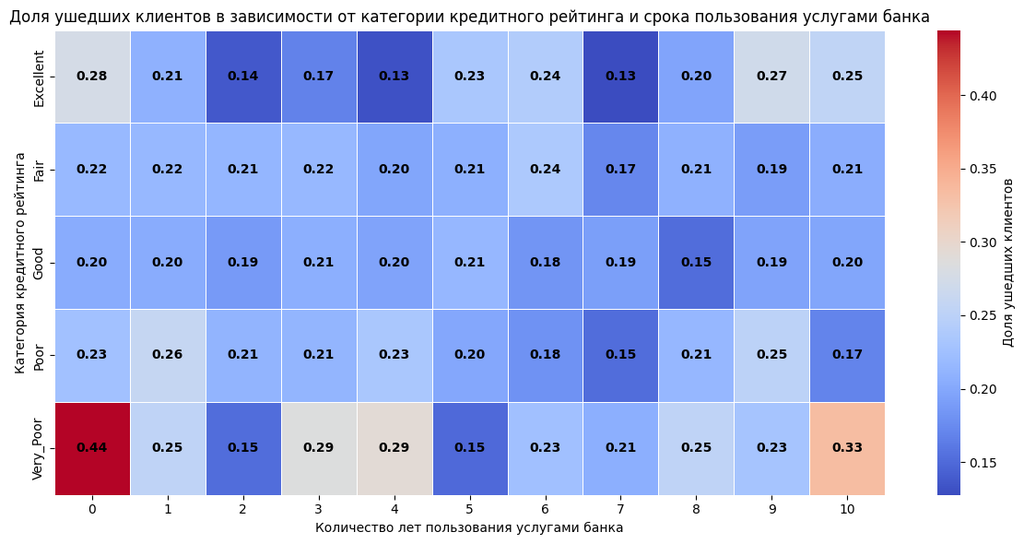

```python
# Пример функции для преобразования CreditScore в категориальный признак
def get_credit_score_cat(credit_score):
    if credit_score >= 300 and credit_score < 500:
        return "Very_Poor"
    elif credit_score >= 500 and credit_score < 601:
        return "Poor"
    elif credit_score >= 601 and credit_score < 661:
        return "Fair"
    elif credit_score >= 661 and credit_score < 781:
        return "Good"
    elif credit_score >= 781 and credit_score < 851:
        return "Excellent"
    elif credit_score >= 851:
        return "Top"
    elif credit_score < 300:
        return "Deep"

# Применим функцию к столбцу CreditScore для создания нового столбца CreditScoreCat
churn_data['CreditScoreCat'] = churn_data['CreditScore'].apply(get_credit_score_cat)

# Построим сводную таблицу
pivot_table = churn_data.pivot_table(
    values='Exited',
    index='CreditScoreCat',
    columns='Tenure',
    aggfunc='mean'
)

# Построим тепловую карту с настройкой аннотаций
plt.figure(figsize=(12, 6))
sbs.heatmap(
    pivot_table,
    annot=True,
    annot_kws={'size': 10, 'weight': 'bold', 'color': 'black'},  # Настройки для аннотаций
    cmap='coolwarm',
    fmt='.2f',
    linewidths=0.5,
    cbar_kws={'label': 'Доля ушедших клиентов'}
)
plt.title('Доля ушедших клиентов в зависимости от категории кредитного рейтинга и срока пользования услугами банка')
plt.xlabel('Количество лет пользования услугами банка')
plt.ylabel('Категория кредитного рейтинга')
plt.tight_layout()
plt.show()
```

```python
# Общая статистика для всех числовых столбцов
print(churn_data.describe())
```

```
         RowNumber    CustomerId   CreditScore           Age        Tenure  \
count  10000.00000  1.000000e+04  10000.000000  10000.000000  10000.000000
mean    5000.50000  1.569094e+07    650.528800     38.921800      5.012800
std     2886.89568  7.193619e+04     96.653299     10.487806      2.892174
min        1.00000  1.556570e+07    350.000000     18.000000      0.000000
25%     2500.75000  1.562853e+07    584.000000     32.000000      3.000000
50%     5000.50000  1.569074e+07    652.000000     37.000000      5.000000
75%     7500.25000  1.575323e+07    718.000000     44.000000      7.000000
max    10000.00000  1.581569e+07    850.000000     92.000000     10.000000

             Balance  NumOfProducts    HasCrCard  IsActiveMember  \
count   10000.000000   10000.000000  10000.00000    10000.000000
mean    76485.889288       1.530200      0.70550        0.515100
std     62397.405202       0.581654      0.45584        0.499797
min         0.000000       1.000000      0.00000        0.000000
25%         0.000000       1.000000      0.00000        0.000000
50%     97198.540000       1.000000      1.00000        1.000000
75%    127644.240000       2.000000      1.00000        1.000000
max    250898.090000       4.000000      1.00000        1.000000

       EstimatedSalary        Exited
count     10000.000000  10000.000000
mean     100090.239881      0.203700
std       57510.492818      0.402769
min          11.580000      0.000000
25%       51002.110000      0.000000
50%      100193.915000      0.000000
75%      149388.247500      0.000000
max      199992.480000      1.000000
```

```python
# Частотный анализ для категориального столбца
print(churn_data['CreditScoreCat'].value_counts())
print(churn_data['Tenure'].value_counts())
```

```
CreditScoreCat
Good         3703
Poor         2434
Fair         2281
Excellent     950
Very_Poor     632
Name: count, dtype: int64
Tenure
2     1048
1     1035
7     1028
8     1025
5     1012
3     1009
4      989
9      984
6      967
10     490
0      413
Name: count, dtype: int64
```

```python
# Группировка данных по категории кредитного рейтинга
grouped = churn_data.groupby('CreditScoreCat')['Exited'].mean()
print(grouped)
```

```
CreditScoreCat
Excellent    0.196842
Fair         0.206050
Good         0.193087
Poor         0.211586
Very_Poor    0.237342
Name: Exited, dtype: float64
```

**Анализ тенденций:**

**Выводы для банка:**